# DATS 6101 - Midterm

### Android Version vs. Installs

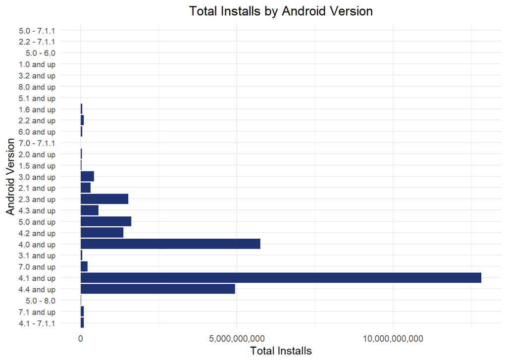

```r
ggplot(data_clean, aes(x = reorder(Android.Ver, -Installs), y = Installs)) +
  geom_bar(stat = "identity", fill = "#1f3374") +
  coord_flip() +  # Flip coordinates for better readability
  scale_y_continuous(labels = scales::comma) +  # Format y-axis with commas
  theme_minimal() +
  labs(
    title = "Total Installs by Android Version",
    x = "Android Version",
    y = "Total Installs"
  ) +
  theme(
    axis.text.y = element_text(size = 8),  # Adjust y-axis text size
    plot.title = element_text(hjust = 0.5)  # Center the plot title
  )
```

### Android Version vs. Reviews

```r
data_clean <- data_clean %>%
  filter(!is.na(Android.Ver) & !is.na(Reviews)) %>%
  mutate(Scaled_Reviews = log10(Reviews + 1))
```

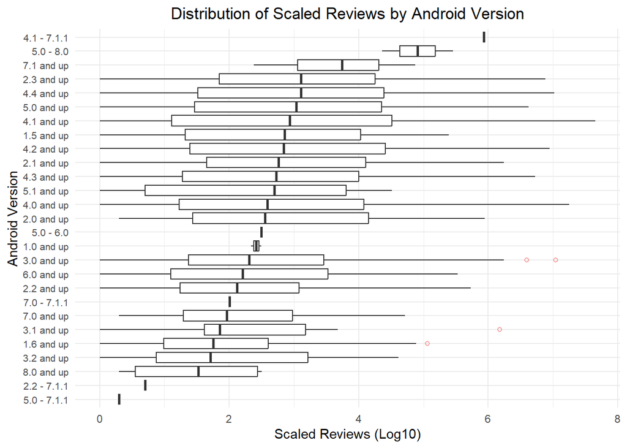

```r
ggplot(data_clean, aes(x = reorder(Android.Ver, Scaled_Reviews, FUN = median), y = Scaled_Reviews)) +
  geom_boxplot(outlier.color = "#f05555", outlier.shape = 1) +  # Boxplot with red outliers
  coord_flip() +  # Flip coordinates for better readability
  theme_minimal() +
  labs(
    title = "Distribution of Scaled Reviews by Android Version",
    x = "Android Version",
    y = "Scaled Reviews (Log10)"
  ) +
  theme(
    axis.text.y = element_text(size = 8),  # Adjust y-axis text size
    plot.title = element_text(hjust = 0.5)  # Center the plot title
  )
```

### Android Version vs. Rating

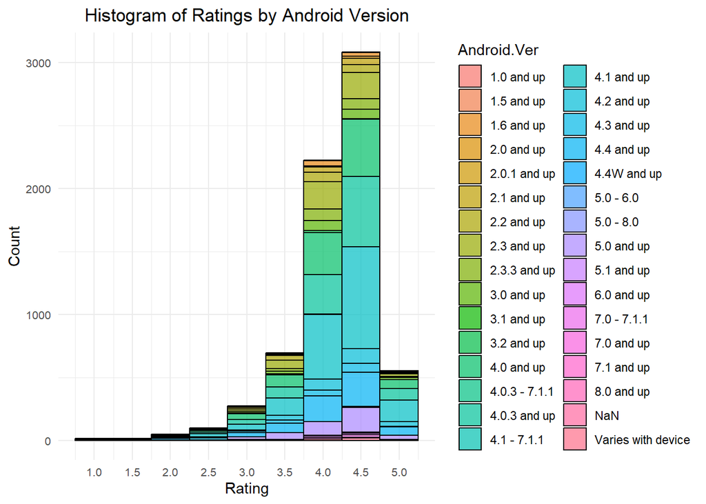

```r
ggplot(df_clean, aes(x = Rating, fill = Android.Ver)) +
  geom_histogram(binwidth = 0.5, position = "stack", color = "black", alpha = 0.7) +
  scale_x_continuous(breaks = seq(1, 5, by = 0.5)) +  # Set x-axis breaks
  theme_minimal() +
  labs(
    title = "Histogram of Ratings by Android Version",
    x = "Rating",
    y = "Count"
  ) +
  theme(
    axis.text.x = element_text(size = 8),
    axis.text.y = element_text(size = 8),
    plot.title = element_text(hjust = 0.5)  # Center the plot title
  )
```

```r
data_final <- data_clean %>% select(-c('Genres', 'Current.Ver'))
str(data_final)
```

```
## 'data.frame':    6979 obs. of  13 variables:
##  $ App           : chr  "Sketch - Draw & Paint" "Pixel Draw - Number Art Coloring Book" "Paper flowers instructions" "Infinite Painter" ...
##  $ Category      : chr  "ART_AND_DESIGN" "ART_AND_DESIGN" "ART_AND_DESIGN" "ART_AND_DESIGN" ...
##  $ Rating        : num  4.5 4.3 4.4 4.1 4.4 4.4 4.4 4.2 4.6 4.4 ...
##  $ Reviews       : num  215644 967 167 36815 13791 ...
##  $ Size          : chr  "25M" "2.8M" "5.6M" "29M" ...
##  $ Installs      : num  5e+07 1e+05 5e+04 1e+06 1e+06 1e+06 1e+06 1e+07 1e+05 1e+05 ...
##  $ Price         : num  0 0 0 0 0 0 0 0 0 0 ...
##  $ Content.Rating: chr  "Teen" "Everyone" "Everyone" "Everyone" ...
##  $ Last.Updated  : chr  "June 8, 2018" "June 20, 2018" "March 26, 2017" "June 14, 2018" ...
##  $ Android.Ver   : chr  "4.2 and up" "4.4 and up" "2.3 and up" "4.2 and up" ...
##  $ log_Installs  : num  17.7 11.5 10.8 13.8 13.8 ...
##  $ Android_Ver   : Named num  4.2 4.4 2.3 4.2 3 4.1 4 4.1 4.4 2.3 ...
##   ..- attr(*, "names")= chr [1:6979] "4.2 and up" "4.4 and up" "2.3 and up" "4.2 and up" ...
##  $ Scaled_Reviews: num  5.33 2.99 2.23 4.57 4.14 ...
```

Lets do bivariate analysis on price and other variables from now.

### Price vs Installs

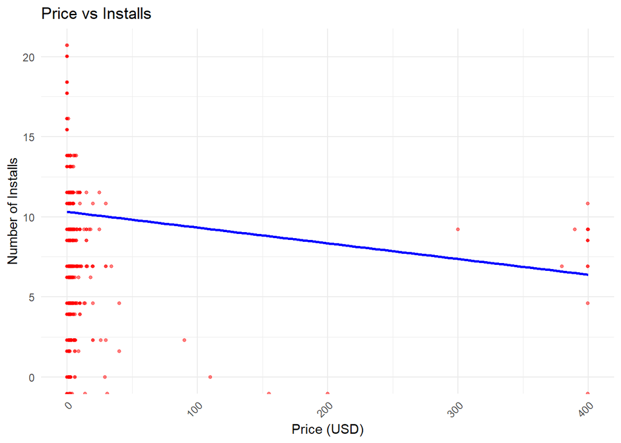

```r
library(ggplot2)
#Plotting a scatter plot between Price and installs
ggplot(data_final, aes(x=Price, y=log_Installs)) +
  geom_point(color = 'red', size = 1, alpha = 0.5) +
  geom_smooth(method = 'lm', color = 'blue', se = FALSE) +
  labs(title = "Price vs Installs", x = "Price (USD)", y = "Number of Installs") +
  theme_minimal() +
  theme(axis.text.x = element_text(angle = 45, hjust = 1))
```

From the scatter plot, we can see that there are more number of installations with price value 0.

```r
# Categorize the apps as "Free" or "Paid" based on Price
Price_Category <- ifelse(data_final$Price == 0, "Free", "Paid")
str(data_final$Price)
```

```
##  num [1:6979] 0 0 0 0 0 0 0 0 0 0 ...
```

```r
str(Price_Category)
```

```
##  chr [1:6979] "Free" "Free" "Free" "Free" "Free" "Free" "Free" "Free" ...
```

```r
str(data_final$log_Installs)
```

```
##  num [1:6979] 17.7 11.5 10.8 13.8 13.8 ...
```

For a better visualization, we are categorizing price values 0 as free apps and plotting abox plot.

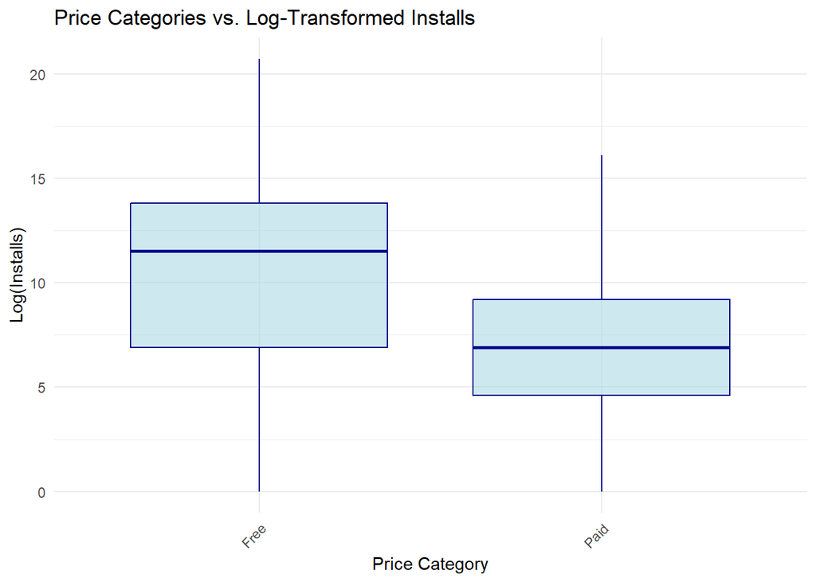

```r
# Box plot of Price Category vs. log-transformed Installs
ggplot(data_final, aes(x = Price_Category, y = log_Installs)) +
  geom_boxplot(fill = "lightblue", color = "darkblue", alpha = 0.6) +
  labs(title = "Price Categories vs. Log-Transformed Installs",
       x = "Price Category",
       y = "Log(Installs)") +
  theme_minimal() +
  theme(axis.text.x = element_text(angle = 45, hjust = 1))
```

```r
# Check for missing values and ensure no negative/zero values in log_Installs
data_final <- data_final %>%
  filter(!is.na(Installs), Installs > 0)  # Remove missing values and zeros in Installs

# Apply log transformation, adding 1 to avoid log(0)
data_final$log_Installs <- log(data_final$Installs + 1)

# Ensure Price_Category has no missing values
#data_final <- data_final %>%
 # filter(!is.na(Price_Category))

# Perform t-test on log-transformed Installs by Price Category
#t_test_result <- t.test(log_Installs ~ Price_Category, data = data_final, var.equal = FALSE)

# Print t-test results
#print(t_test_result)
```

From the above analysis, we can practically state that free apps are more popular than paid apps, which can be considered true in the app market.

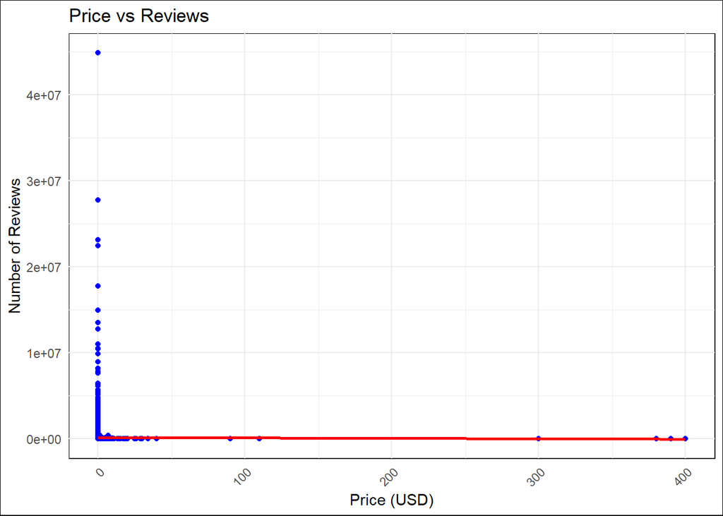

```r
# Plot Price vs. Reviews
ggplot(data_final, aes(x=Price, y=Reviews)) +
  geom_point(color = 'blue') +
  geom_smooth(method = 'lm', color = 'red', se = FALSE) +
  labs(title = "Price vs Reviews", x = "Price (USD)", y = "Number of Reviews") +
  theme_minimal() +
  theme(
    panel.background = element_rect(fill = "white"),  # Set panel background to white
    plot.background = element_rect(fill = "white"),   # Set plot background to white
    axis.text.x = element_text(angle = 45, hjust = 1)
  )
```

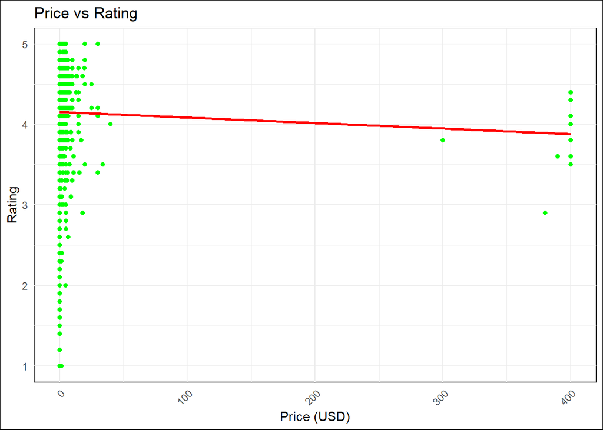

```r
# Plot Price vs. Rating
ggplot(data_final, aes(x=Price, y=Rating)) +
  geom_point(color = 'green') +
  geom_smooth(method = 'lm', color = 'red', se = FALSE) +
  labs(title = "Price vs Rating", x = "Price (USD)", y = "Rating") +
  theme_minimal() +
  theme(
    panel.background = element_rect(fill = "white"),  # Set panel background to white
    plot.background = element_rect(fill = "white"),   # Set plot background to white
    axis.text.x = element_text(angle = 45, hjust = 1)
  )
```

Price vs Reviews with installation: Cheaper products tend to have more reviews, indicating higher popularity or more frequent purchases. In contrast, expensive products tend to have fewer reviews, possibly because fewer people buy higher-priced items.